# Clase3_py

## Curso de introducción a la programación con Python

**Autor: Luis Fernando Apáez Álvarez**  
-Curso PyM-  
Clase 3: Introducción a la POO y la librería Matplotlib  
Fecha: 10 de Agosto del 2022

### Contenido

Un vistazo a las funciones definidas por el usuario

Definiendo Clases

Introducción a la librería Matplotlib

### Introducción

**Python** es un lenguaje de programación multiparadigma, es decir que admite varios tipos de *"estilos"* de programación. Lo anterior nos permite decir que **Python** es, en particular, un lenguaje orientado a objetos, esto es, dentro de **Python** podemos utilizar el *"estilo"* de escribir **Clases** y **Objetos**, así como lo vimos en la presentación.

Un ejemplo claro de ello es lo siguiente:

```python
print(type(3))
```

```
<class 'int'>
```

Al utilizar la función `type()` e imprimir el resultado, vemos que se nos muestra el mensaje `<class 'int'>`, lo cual nos está diciendo básicamente que el `3` es un **objeto** de la **Clase** `int` (*integer*). Lo anterior tiene mucho sentido pues se pude considerar una especie de plantilla de los números enteros, lo que involucra, claro, características generales y funcionalidades generales; de esta manera, cada número entero es un objeto o una instancia de esta plantilla. En particular, el `3` es un objeto de la clase `int`. De manera totalmente análoga podemos decir (o ver) que

```python
# clase de flotantes
print(type(3.1416))
print()

# Clase de cadenas de texto
print(type("Hola Mundo!"))
print()

# Clase de booleanos
print(type(False))
```

```
<class 'float'>

<class 'str'>

<class 'bool'>
```

Continuando con lo dicho en la presentación, en esta primer parte de la sesión trabajaremos con el ejemplo de la **Clase Persona**. Recordemos que una clase puede entenderse, de manera intuitiva, como una generalización o una especie de plantilla, y los **objetos** de dicha clase se pueden entender como elementos de la clase que cumplen con las especificaciones dictadas en la plantilla.

De tal manera, construiremos primero la plantilla de la **Clase persona**, para lo cual requerimos de dos ingredientes:

- Atributos o características: en nuestra plantilla manejaremos únicamente los atributos de *nombre* y *edad*.
- Funcionalidades o métodos: consideraremos en la plantilla las funcionalidades de *hablar* y *caminar*.

Antes de que podamos implementar en código nuestra plantilla de **Persona**, es necesario dar un vistazo a un tema importante dentro de la programación:

### Un vistazo a las funciones definidas por el usuario

Recordemos de las primeras sesiones que dentro de **Python** existen funciones que por *default* vienen integradas, por ejemplo

```python
# la puncion type()
# la función print()

print( type(2) )
```

```
<class 'int'>
```

Este tipo de funciones que vienen por *default* se conocen como *funciones predefinidas* porque, justamente, ya fueron definidas. Lo anterior nos permite entonces considerar la posibilidad de definir, de manera propia, otro tipo de funciones. En efecto, dentro de **Python** podemos definir funciones propias (denominadas *funciones definidas por el usuario*) que realicen algunas acciones que necesitemos o sea de nuestro interés. Antes de ver de lleno este tipo de funciones, recordemos la idea intuitiva sobre las **funciones matemáticas**.

Una función $f$ puede verse como una especie de máquina, en la cual nosotros ingresaremos algo y la función (o máquina) realiza un proceso de lo que ingresamos para entregarnos un resultado. Un ejemplo de lo anterior puede ser

[figure not shown]

En una tortillería vemos que ocurre lo siguiente: se **ingresa** masa (valor del parámetro) a la **máquina**(función) y se devuelve (salida) tortillas. De tal manera, las funciones matemáticas actúan como

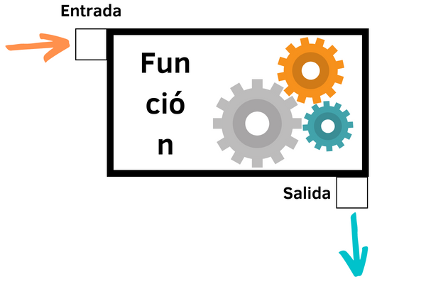

Un ejemplo más concreto es la función matemática $f(x)=x^{2}$, donde esta función actúa como:

- ingresas un número (valor del parámetro), la función lo "procesa" y arroja (salida) dicho número elevado al cuadrado

Por ejemplo, podemos considerar $f(2)=(2)^{2}=4$:

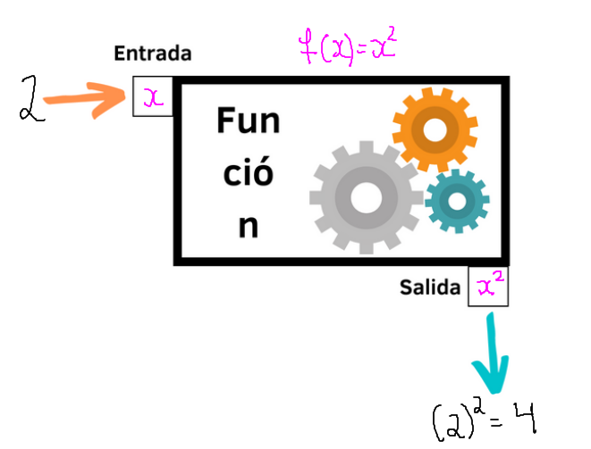

De tal manera, las funciones que definiremos dentro de **Python** poseen la misma idea intuitiva que las funciones matemáticas; esto es, las funciones que definiremos tendrán parámetros y los valores que se ingresen en dichos parámetros serán procesados mediante instrucciones o acciones que nosotros definamos, para finalmente devolver un resultado.

La sintaxis básica para definir una función es:

```
def <<nombre de tu función>> (<<aqui van tus parametros>>):
    procesamiento o instrucciones a realizar
    utilizando (o no) los parámetros
    return <<salida de la función>>
```

Entonces, por ejemplo, podemos llevar la función matemática $f(x)=x^{2}$ a código escribiendo lo siguiente

```python
# Definiremos la funcion f(x)=x^{2}:
# x es el unico parametro,
# la funcion debe calcular el parametro elevado
# al cuadrado,
# la funcion debe devolver el resultado anteriormente
# calculado

def elevar_cuadrado(x):
    # calculamos el cuadrado del parametro
    valor_cuadrado = x ** 2
    # devolvemos dicho valor
    return valor_cuadrado
```

donde:

- `elevar_cuadrdo` es el nombre de nuestra función
- `x` es el nombre del parámetro de nuestra función
- `valor_cuadrado` es una variable que almacena el valor de `x ** 2`
- `return valor_cuadrado` es la instrucción para devolver o regresar el valor calculado anteriormente

Probemos nuestra función con algunos valores:

```python
# mostramos el resultado de elevar 2 al cuadrado
print(elevar_cuadrado(2))

print("-" * 20)

# mostramos el resultado de elevar 5 al cuadrado
print(f"5 elevado al cuadrado es: {elevar_cuadrado(5)}")
```

```
4
--------------------
5 elevado al cuadrado es: 25
```

De manera alternativa también pudimos haber escrito

```python
# Manera compacta:
# definimos una funcion que se denomine f,
# que reciba como parametro x
# y que nos regrese el valor de x ** 2+
def f(x):
    return x ** 2

# Probamos nuestra funcion
print(f(7))
```

```
49
```

También podemos emplear funciones que no tengan salida, es decir, la cláusula `return` es opcional

```python
# creamos una funcion para mostrar un mensaje
def mensaje(msj):
    print(msj)

# podemos a prueba nuestra funcion
mensaje("Hola")
```

```
Hola
```

En este caso la función anterior no regresó ningún valor, lo que pasó fue que dentro del procesamiento de la función `mensaje` se ejecutó la función predefinida `print()`, con lo cual el mensaje que ingresamos en nuestra función fue mostrado. De la misma manera, podemos definir funciones sin parámetros:

```python
# creamos una funcion que salude
def msj_hola():
    print("Hola")

# podemos a prueba nuestra funcion
msj_hola()

print("-" * 20)

# O alternativamente
# creamos una funcion que salude
def msj_hola2():
    return "Hola"

# podemos a prueba nuestra funcion
print(msj_hola2())
```

```
Hola
--------------------
Hola
```

### Definiendo Clases

Ahora bien, nuestra labor será definir la plantilla **Persona** con las especificaciones que se indicaron antes. Para definir una **Clase** en **Python** utilizaremos la palabra reservada `class` mediante la siguiente estructura:

```
class <<nombre de la clase>>:
    definimos los atributos de la clase
    .
    .
    .
    definimos los métodos (o funcionalidades) de la clase
```

donde podemos decir que los métodos (o funcionalidades) de la clase no son más que funciones definidas por el usuario.

Con base en lo anterior podemos definir la **Clase Persona** como sigue:

```python
# Clase Persona
class Persona:
    # ---------------Atributos----------------

    # Definimos los atributos,
    # los atributos no son mas que variables
    # Atributo nombre:
    nombre = ""
    # Atributo edad:
    edad = 0
    # Atributo auxiliar que ocuparemos
    # en los metodos:
    hablando = False
    # Atributo auxiliar:
    caminando = False

    # ----------------Metodos-----------------

    # Definimos los metodos
    # Metodo para hablar
    def hablar(self):
        self.hablando = True
    # Metodo para caminar
    def caminar(self):
        self.caminando = True
```

donde

- El atributo `nombre` es una cadena vacía pues este atributo sólo nos sirve, en la plantilla, para indicar que las Personas tienen un nombre, así que cada persona tendrá un nombre distinto (en teoría) y por ello, en cada persona cambiaremos el valor de la variable `nombre`. Por ejemplo, en vez de `""` podemos tener `"Luis"`, `"Lola"`, etcétera.
- De manera análoga, definimos el atributo (variable) `edad` inicializándola con el valor de cero.
- Tenemos además dos variables auxiliares, las cuales ocuparemos en los métodos para simular si una persona está hablando (True) o no (False), o, esta caminando o no. Por ejemplo, si una persona en particular "está hablando", entonces el valor de la variable `hablando` debe ser `True`; si no está hablando, entonces el valor correspondiente debe ser el de `False`.
- Colocando como parámetro de los métodos la cláusula `self`, indicamos a **Python** que dicha función actuará internamente dentro de la clase utilizando propiamente los atributos de la misma. Esto es, al nosotros utilizar como parámetro el `self`, estamos haciendo una distinción marcada entre métodos (funciones propias de una clase) y las funciones definidas por el usuario. De la misma manera, al escribir `self.hablando` estamos declarando que la variable a la que nos estamos refiriendo es justamente un atributo de la clase. Si no colocamos el `self`, entonces **Python** no sabe identificar si nos estamos refiriendo a un atributo de la clase o a cualquier otra variable, lo cual conduciría a un error en la ejecución.
- El método `hablar()` lo que hace es cambiar el valor de la variable `hablando` de `False` a `True` para simular que una persona en especifico está hablando. De manera análoga el funcionamiento del método `caminar()`

Así, estamos preparados para crear nuestro primer objeto de la clase persona:

```python
# creremos un objeto de la clase persona
# y a dicho objeto lo denominaremos persona1
# (recuerda que '=' significa asignacion)
persona1 = Persona()

# podemos ver la informacion marcada en la
# plantilla de Persona accediento a sus
# atributos

# Para acceder a los atributos de una clase
# utilizamos .<<nombre del atributo>>
# por ejemplo:

# accedemos al valor del atributo nombre de la
# plantilla
print(persona1.nombre)
# accedemos al valor del atributo edad de la
# plantilla
print(persona1.edad)
# accedemos al valor del atributo hablando de la
# plantilla
print(persona1.hablando)
```

```
0
False
```

- En primera instancia, al escribir `persona1 = Persona()` estamos creando un objeto de la clase Persona, el cual denominaremos como `persona1`. Una vez que creamos un objeto y realizamos la asignación a la clase correspondiente (`= Persona()` en este caso), todas las especificaciones de la clase (atributos y métodos) estarán disponibles para todos los objetos creados.
- Podemos acceder a dichos atributos y métodos utilizando la sintaxis `.<<nombre del atributo o metodo>>`, por ejemplo `persona1.nombre` (que al ser impreso nos arrojó la cadena vacía).
- Podemos cambiar los valores por defecto que declaramos en los atributos realizando una asignación al nuevo valor, por ejemplo, podemos cambiar la cadena vacía almacenada en el atributo nombre, a la cadena `"Luis"`:

```python
# asignamos "Luis" al atributo 'nombre'
# correspondiente al objeto persona1
persona1.nombre = "Luis"

# imprimimos el cambio
print(persona1.nombre)
```

```
Luis
```

De manera análoga:

```python
# cambiamos el valor del atributo edad
persona1.edad = 24
print(persona1.edad)
```

```
24
```

Ahora, supongamos que la persona comenzará a hablar, por lo cual el valor del atributo `hablando` debe cambiar de `False` a `True`, lo que conseguimos ejecutando el método `hablar()`

```python
# notamos primero que la persona no esta hablando
# porque justamente el valor del atributo hablando
# es False
print(persona1.hablando)

print("-" * 30)

# mandamos a llamar el metodo hablar()
# para simular que la persona1 esta
# hablando
persona1.hablar()

# veamos que ahora el valor del atributo
# hablando correspondiente a la persona 1
# es el de True
print(persona1.hablando)
```

```
False
------------------------------
True
```

### Introducción a la librería Matplotlib

Dentro de **Python** existen librerías o paquetes los cuales traen consigo nuevas funcionalidades y que sirven a diversos fines. Por ejemplo, hay librerías que nos permiten enfocarnos en el *Machine Learning*, en el *procesamiento del lenguaje natural*, en el *cálculo numérico*, en la *visualización*, etcétera. Ahora bien, cada librería representa un conjunto de módulos, donde un módulo representa un archivo **Python** en el cual puede haber funciones, clases, variables, etcétera.

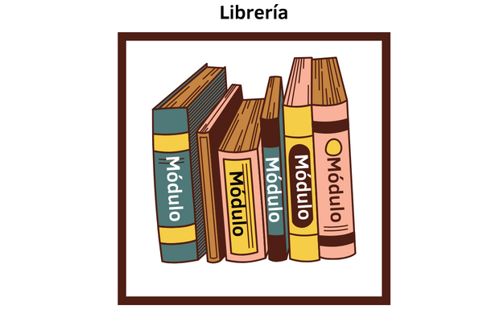

Así, la librería que veremos a continuación se donimina `matplotlib`, la cual sirve para las visualizaciones en **Python**, es decir, nos permite crear diversos gráficos.

Lo primero que debemos hacer es importar dicha librería en nuestro espacio de trabajo (es decir, en nuestra notebook). En especifico, en esta clase trabajaremos con el módulo `pyplot` para realizar gráficos, por lo cual realizaremos la importación del módulo `pyplot` de la librería `matplotlib`. Además, a dicho módulo le daremos un alias para trabajar con él de una manera más sencilla

```python
# as <<nombre>> corresponde a la asignacion de un alias
# En este caso el alias que suele darse a este modulo
# es el de plt
import matplotlib.pyplot as plt
```

A partir de ahora, todas las funcionalidades del módulo `pyplot` están disponibles y podemos acceder a ellas utilizando el prefijo `plt.` seguido de la funcionalidad que queremos llevar a cabo.

Lo primero que haremos será graficar un punto, para lo cual utilizaremos la función `plot()` del módulo `pyplot`. Para llamar a dicha función escribiremos entonces `plt.plot()`, donde los parámetros serán, por ahora, las coordenadas del punto a graficar. Entonces

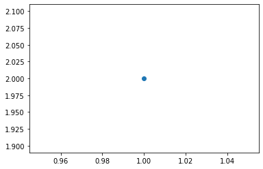

```python
# Graficaremos el punto coordenado (1,2)

# Creamos el grafico deseado utilizando la funcion
# plt.plot(1,2)
# Pero ademas, dentro de los parametros especificaremos
# el tipo de marcador o rotulador (marker) con el cual
# nuestro punto sera graficado.
plt.plot(1,2, marker="o")

# una vez creado el grafico, queremos que
# este se muestre. Para ello emplearemos
# la función plt.show()
plt.show()
```

donde podemos ver que `marker="o"` hace que nuestro punto coordenado tenga la forma, justamente, de un punto. Veamos otros tipos de marcadores, donde en el siguiente código graficaremos más de un punto coordenado

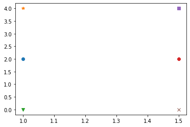

```python
# podemos graficar de forma simultanea
# muchos puntos
plt.plot(1,2, marker="o")
plt.plot(1,4, marker="*")
plt.plot(1,0, marker="v")
plt.plot(1.5,2, marker="8")
plt.plot(1.5,4, marker="s")
plt.plot(1.5,0, marker="x")

# mostramos el grafico
plt.show()
```

Si quieres consultar más tipos de marcadores puedes ver [Matplotlib markers](https://matplotlib.org/stable/api/markers_api.html)

Adicionalmente, podemos agregar un cuadrículado a nuestro gráfico anterior, para lo cual utilizaremos la función `plt.grid()`

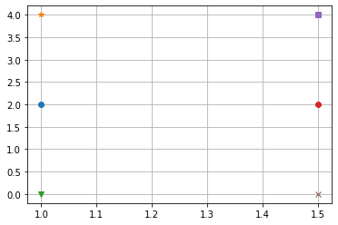

```python
# podemos graficar de forma simultanea
# muchos puntos
plt.plot(1,2, marker="o")
plt.plot(1,4, marker="*")
plt.plot(1,0, marker="v")
plt.plot(1.5,2, marker="8")
plt.plot(1.5,4, marker="s")
plt.plot(1.5,0, marker="x")

# agregamos un cuadriculado
plt.grid()

# mostramos el grafico
plt.show()
```

Podemos agregar etiquetas para especificar cada tipo de punto del gráfico anterior, para ello agregaremos un parámetro adicional en la función `plt.plot()`, el cual es `label="etiqueta"`, donde en `etiqueta` colocaremos el texto que queramos

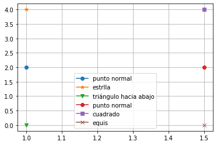

```python
# podemos graficar de forma simultanea
# muchos puntos
# Agregaremos etiquetas en cada uno de los puntos
plt.plot(1,2, marker="o", label="punto normal")
plt.plot(1,4, marker="*", label="estrlla")
plt.plot(1,0, marker="v", label="triángulo hacia abajo")
plt.plot(1.5,2, marker="8", label="punto normal")
plt.plot(1.5,4, marker="s", label="cuadrado")
plt.plot(1.5,0, marker="x", label="equis")

# agregamos un cuadriculado
plt.grid()

# esta funcion muestra las etiquetas
# de cada plt.plot()
plt.legend()

# mostramos el grafico
plt.show()
```

Podemos agregar texto dentro de nuestro gráfico, para lo cual deberemos especificar la coordenada en la cual queremos posicionar dicho texto

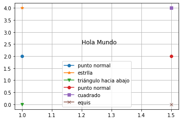

```python
# Unos puntos
plt.plot(1,2, marker="o", label="punto normal")
plt.plot(1,4, marker="*", label="estrlla")
plt.plot(1,0, marker="v", label="triángulo hacia abajo")
plt.plot(1.5,2, marker="8", label="punto normal")
plt.plot(1.5,4, marker="s", label="cuadrado")
plt.plot(1.5,0, marker="x", label="equis")

# agregamos texto con la funcion plt.text() como sigue
# en la coordenada (1.2,2.5) agregaremos el texto "Hola Mundo"
# especificando el tamagno de la letra en 12
plt.text(1.2, 2.5, "Hola Mundo", fontsize=12)

# agregamos un cuadriculado
plt.grid()

# esta funcion muestra las etiquetas
# de cada plt.plot()
plt.legend()

# mostramos el grafico
plt.show()
```

Podemos agregar etiquetas a los ejes $x$ (`plt.xlabel()`) y $y$ (`plt.ylabel()`), asimismo, podemos agregar un título (`plt.title()`) a nuestro gráfico como sigue

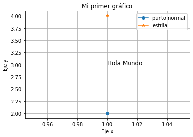

```python
# Unos puntos
plt.plot(1,2, marker="o", label="punto normal")
plt.plot(1,4, marker="*", label="estrlla")

# agregamos texto en la coordenad (1,3)
plt.text(1, 3, "Hola Mundo", fontsize=12)

# agregamos un cuadriculado
plt.grid()

# esta funcion muestra las etiquetas
plt.legend()

# agregamos etiquetas a los ejes
plt.xlabel("Eje x")
plt.ylabel("Eje y")

# agregamos un titulo
plt.title("Mi primer gráfico")

# mostramos el grafico
plt.show()
```

También, podemos cambiar el color de los puntos, lo cual lograremos agregando el parámetro `color="nombre del color"` a la función `plt.plot()`:

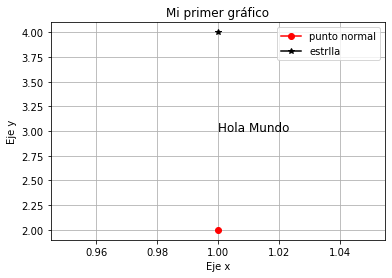

```python
# Unos puntos
# Cambiaremos su color
plt.plot(1,2, marker="o", label="punto normal", color="red")
plt.plot(1,4, marker="*", label="estrlla", color="black")

# agregamos texto en la coordenad (1,3)
plt.text(1, 3, "Hola Mundo", fontsize=12)

# agregamos un cuadriculado
plt.grid()

# esta funcion muestra las etiquetas
plt.legend()

# agregamos etiquetas a los ejes
plt.xlabel("Eje x")
plt.ylabel("Eje y")

# agregamos un titulo
plt.title("Mi primer gráfico")

# mostramos el grafico
plt.show()
```

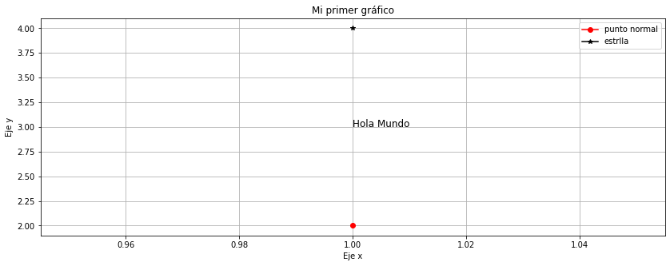

```python
# cambiaremos el tamagno de salida del grafico
# figsize=(largo, ancho)
plt.figure(figsize=(14, 5))

# Unos puntos
plt.plot(1,2, marker="o", label="punto normal", color="red")
plt.plot(1,4, marker="*", label="estrlla", color="black")
# agregamos texto en la coordenad (1,3)
plt.text(1, 3, "Hola Mundo", fontsize=12)
# agregamos un cuadriculado
plt.grid()
# esta funcion muestra las etiquetas
plt.legend()
# agregamos etiquetas a los ejes
plt.xlabel("Eje x")
plt.ylabel("Eje y")
# agregamos un titulo
plt.title("Mi primer gráfico")
# mostramos el grafico

plt.show()
```

Finalmente, hay distintos estilos o tipos de graficación, por ejemplo, podemos usar un estilo de gráficación denominado `ggplot`:

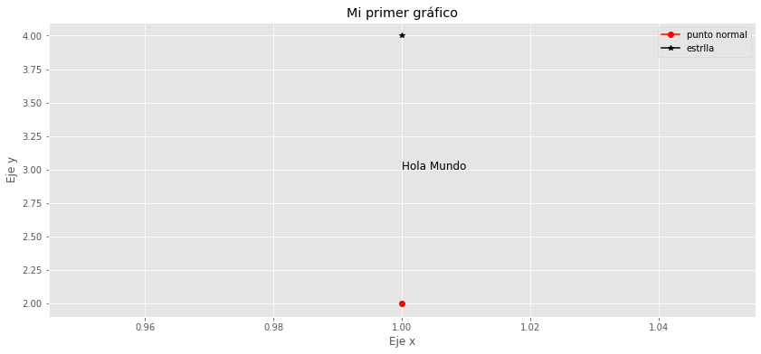

```python
# Podemos configurar cierto tipo de
# estilo de graficacion
plt.style.use('ggplot')

# ---------------------------------------------------------
# ---------------------------------------------------------
# ---------------------------------------------------------

# cambiaremos el tamagno de salida del grafico
# figsize=(largo, ancho)
plt.figure(figsize=(14, 6))
# Unos puntos
plt.plot(1,2, marker="o", label="punto normal", color="red")
plt.plot(1,4, marker="*", label="estrlla", color="black")
# agregamos texto en la coordenad (1,3)
plt.text(1, 3, "Hola Mundo", fontsize=12)
# esta funcion muestra las etiquetas
plt.legend()
# agregamos etiquetas a los ejes
plt.xlabel("Eje x")
plt.ylabel("Eje y")
# agregamos un titulo
plt.title("Mi primer gráfico")
# mostramos el grafico
plt.show()
```